# Surface Water

# The Prompt

Background: The attached Excel file (Dataset_C) contains analytical chemistry data from a variety of surface water stations.

Given the attached dataset:

- Develop a tool for plotting time series by station and analyte.
- Symbolize data by season.
- Add a horizontal line for the mean concentration to each plot.
- Which analytes have the most seasonal variability? What tools/approach did you use?
- Produce a pdf of your plots.

# First Forays and Data Explorations

Before creating the final products, I’ve done some preparation and basic exploration, generally scoping out the data set, and preparing it for downstream analysis.

```r
rm(list=ls()) # Clear working environment

library("MapSuite") #Self-written library, has many common libs as dependencies
library("hexbin") # For the hex-bin plots

# Read in surface water observations as data.table sw
  sw<-fread("/Users/stubbsrw/Documents/git_code/stubbs_repo/fe_problems/data/Dataset_C.csv")

# Parse out date information from character date column
  sw[,index:=seq(1:nrow(sw))]
  sw[,Month:=as.numeric(strsplit(SampleDate,"/")[[1]][1]),by=index]
  sw[,Day:=as.numeric(strsplit(SampleDate,"/")[[1]][2]),by=index]
  sw[,Year:=as.numeric(strsplit(SampleDate,"/")[[1]][3]),by=index]
  sw[,Date:=as.IDate(paste0((2000+Year),"-",Month,"-",Day))] # Create formal column of integer-date

# For each analyte, discover the minimum date, and generate a month index from that date:
  sw[,year_index:=Year-min(Year,na.rm=T),by=StandardAnalyte]
  sw[,year_min:=min(Year,na.rm=T),by=StandardAnalyte] # First sample year, calculated by each analyte
  sw[,month_index:=12*(Year-year_min) + Month] # Number of months from the start of the samples

# Add variables on mean concentration for each analyte by site and globally/for all samples
  sw[,mean_concentration_analyte_station:=mean(StandardResult,na.rm=T),by=list(StationName,StandardAnalyte)]
  sw[,mean_concentration_analyte:=mean(StandardResult,na.rm=T),by=StandardAnalyte]
```

## Assign seasons to different months

In order to symbolize by season, you first need to define what data points are in each season. For now, I’m lumping observations into seasons by month. You could do this a fancier way if you wanted, based on cut points of the equinoxes; for now, we’ll just go with month-by-month approximations. I’m also assuming that this is in the Northern hemisphere…

```r
sw[Month %in% c(12,1,2), Season:='Winter']
sw[Month %in% c(3,4,5), Season:='Spring']
sw[Month %in% c(6,7,8), Season:='Summer']
sw[Month %in% c(9,10,11), Season:='Fall']
sw[,Month_String:=month.abb[Month]]
sw[,log_obs:=log(StandardResult)] # Just in case a log-transform would be more informative, although NaNs will exist where the observation is negative
sw[,Season:=factor(Season, levels = c("Winter","Spring","Summer","Fall"))] # Defining Season as a factor variable
```

## Exploring a single analyte as a test case

### Plotting Temperature over the full time series

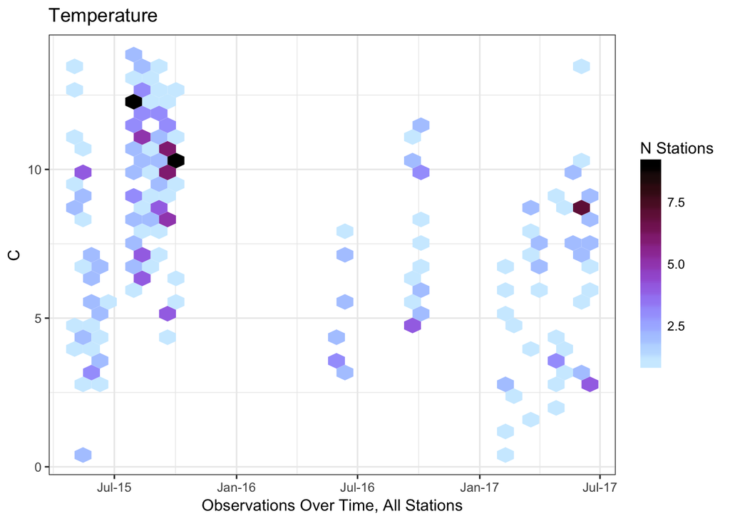

```r
a<-"Temperature" #Picking this one since I have the best sense of what it "should" or "could" be per season

# Make a subset data set with only the analyte you are interested in
analyte<-sw[StandardAnalyte==a]
mean_observation<-mean(analyte$StandardResult)

# Plotting using the HexBin Frequency graphics, where the number of stations with an observation in that category is essentially heat-mapped
ggplot(analyte, aes(x=Date, y=StandardResult)) +
  geom_hex() +
  xlab("Observations Over Time, All Stations") +
  scale_x_date(labels = function(x) format(x, "%b-%y")) +
  ylab(analyte$StandardUnit[1]) +
  ggtitle(paste0(a)) + theme_bw() +
  scale_fill_gradientn(colors=wpal("berries")) +
  guides(fill=guide_colourbar(title="N Stations", title.position="top", barheight=10, barwidth=1,
                              label=TRUE, ticks=FALSE, direction="vertical"))
```

Let’s try pooling observations across stations and also years, to get a rough sense of seasonality from a graphical persepective:

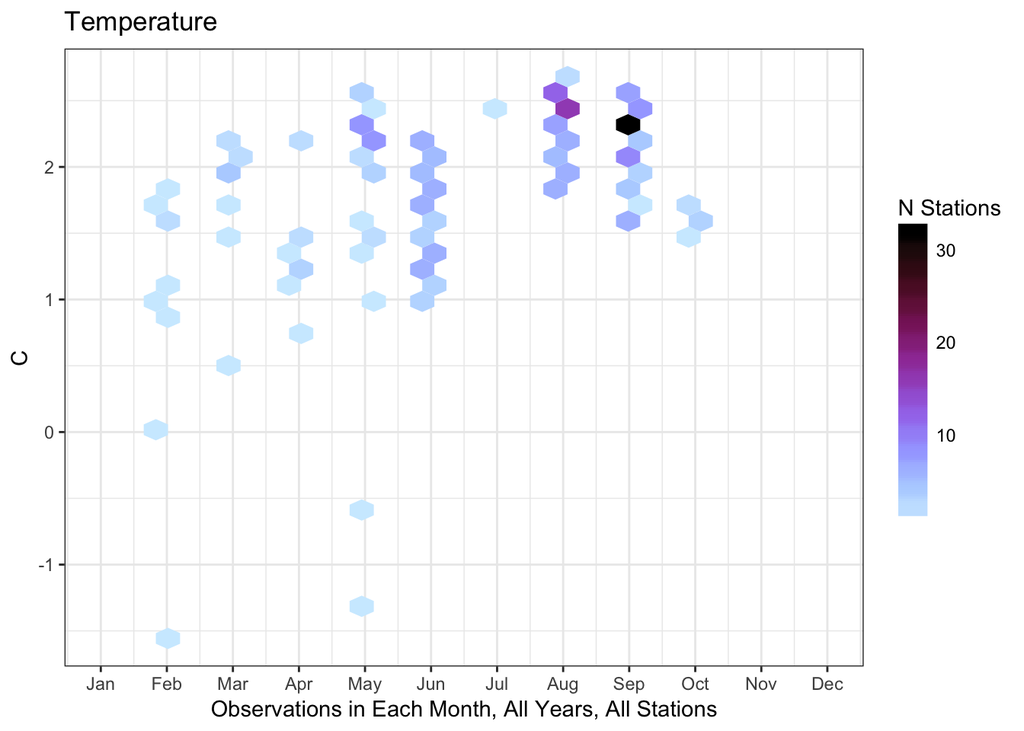

```r
# Plotting by Month, for all years, all stations
months_in_order<-c("Jan","Feb","Mar","Apr","May","Jun","Jul","Aug","Sep","Oct","Nov","Dec")

# Non-Transformed
ggplot(analyte, aes(x= Month, y=log_obs)) + geom_hex() +
  xlab("Observations in Each Month, All Years, All Stations") +
  scale_x_continuous(limits=c(1,12),breaks=seq(1,12), labels=months_in_order) +
  ylab(analyte$StandardUnit[1]) +
  ggtitle(paste0(a)) + theme_bw() +
  scale_fill_gradientn(colors=wpal("berries")) +
  guides(fill=guide_colourbar(title="N Stations", title.position="top", barheight=10, barwidth=1,
                              label=TRUE, ticks=FALSE, direction="vertical"))
```